# Exp7 Analysis

Mrudula Arunkumar

10 May,2021

**This document contains the result memo of Experiment 7 aimed to explore overshadowing in a CL paradigm. It builds on from the design used in Experiment 5 and 6 that showed success in manipulating saliency and validity.But the interaction was not significant in those experiments, Hence, this experiment works towards that aspect by eliminating the contingency guessing trials in between and have two versions: one that resembles learn trials that are presented in the beginning after the headstart trials in a learn block. Then the other one is similar to the ones in the previous experiment that resemble test trials and appear at the end of the experiment.**

Below is the overview of the experiment trials.

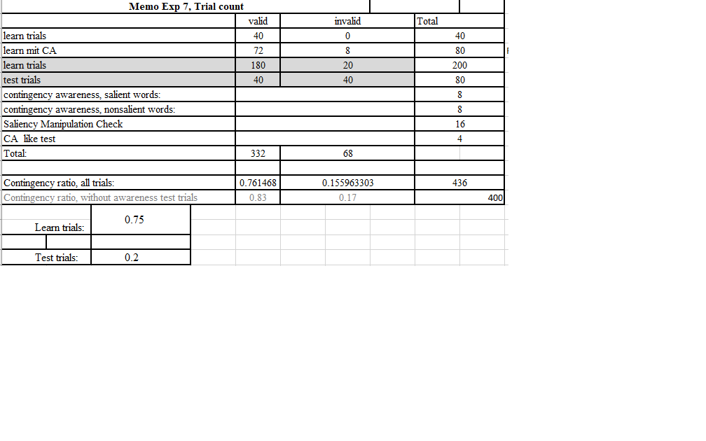

Here are the sample trial displays

- Example Learn Trial with G as a salient letter and X as a non salient pair
- Example test display with salient distractor
- Example test display with nonsalient distractor
- The target is an odd/even number appearing at the centre.

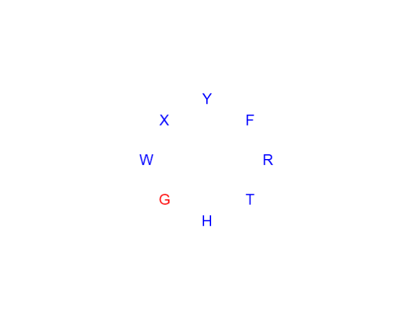

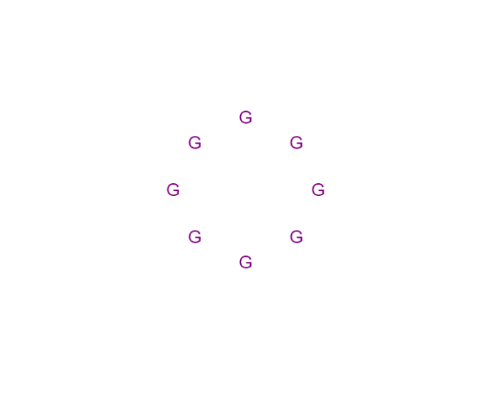

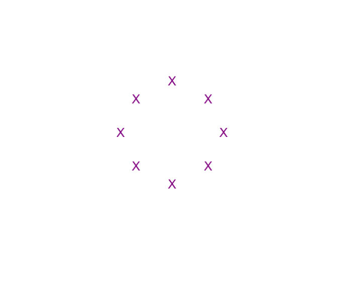

# Data preparation and cleaning

- Removing unnecessary columns generated by psychopy
- Preparing the RT trial, by eliminating the square brackets and splitting it in cases where two keys were registered.
- Creating a column for Accuracy and Error Rate
- adding a Bonus column that computes the points received by each participant

## Descriptives

Summary of the overall Reaction Time, accuracy and Error Rate

Mean RT

| Min. | 1st Qu. | Median | Mean | 3rd Qu. | Max. |
| --- | --- | --- | --- | --- | --- |
| 1.415 | 458.7 | 554.3 | 596.4 | 668.2 | 12563 |

Accuracy

| 0 | 1 |
| --- | --- |
| 1982 | 27554 |

Percentage of errors

| 0 | 1 |
| --- | --- |
| 6.71 | 93.29 |

Upon implementing the exclusion criteria

- Outliers (1.5x above third quartile) –rm> used for the analysis
- Farouts (3x)above third quartile)
- very Fast RTs, less than 200ms

Summary of RT after removing Farouts

| Min. | 1st Qu. | Median | Mean | 3rd Qu. | Max. | NA’s |
| --- | --- | --- | --- | --- | --- | --- |
| 200.3 | 468.6 | 559.8 | 588.4 | 667.6 | 2277 | 2488 |

Summary of RT after removing Outliers

| Min. | 1st Qu. | Median | Mean | 3rd Qu. | Max. | NA’s |
| --- | --- | --- | --- | --- | --- | --- |
| 200.3 | 465.7 | 553.4 | 571.3 | 653.5 | 1733 | 3350 |

# ANALYSES

## EXPERIMENT DESIGN

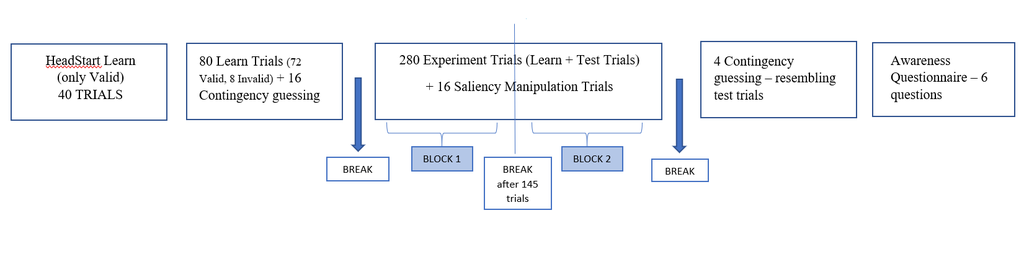

```r
include_graphics(here("Figures","Experiment flow.png"))
```

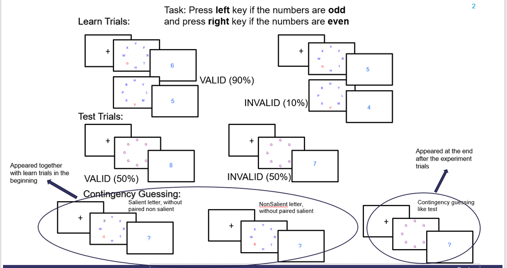

```r
include_graphics(here("Figures", "Experiment design.png"))
```

## 1. Validity Manipulation check - Learn trials

> There is a huge validity effect which is significant with a mean difference of ~50 ms

This shows that participants successfully picked up the association between the letters and the response keys

Table containing means of valid and invalid learn trials, outliers excluded

| Validity | RT_io |
| --- | --- |
| invalid | 616.5 |
| valid | 565 |

t test showing differences between valid and invalid trials-excluding outliers (continued below)

| Test statistic | df | P value | Alternative hypothesis |
| --- | --- | --- | --- |
| 8.521 | 69 | 2.229e-12 * * * | two.sided |

| mean of the differences |
| --- |
| 51.46 |

## 2. Saliency Manipulation Check

This analysis checks whether the saliency manipulation worked by comparing the RT between trials where the number appeared in salient letters position vs non salient letter’s position.

> There is a significant difference between trials where the target appeared at the salient letter position vs non salient letter’s position ($p = 0.01*$)

t test result for saliency manipulation, outliers (continued below)

| Test statistic | df | P value | Alternative hypothesis |
| --- | --- | --- | --- |
| 2.435 | 69 | 0.01749 * | two.sided |

| mean of the differences |
| --- |
| 17.11 |

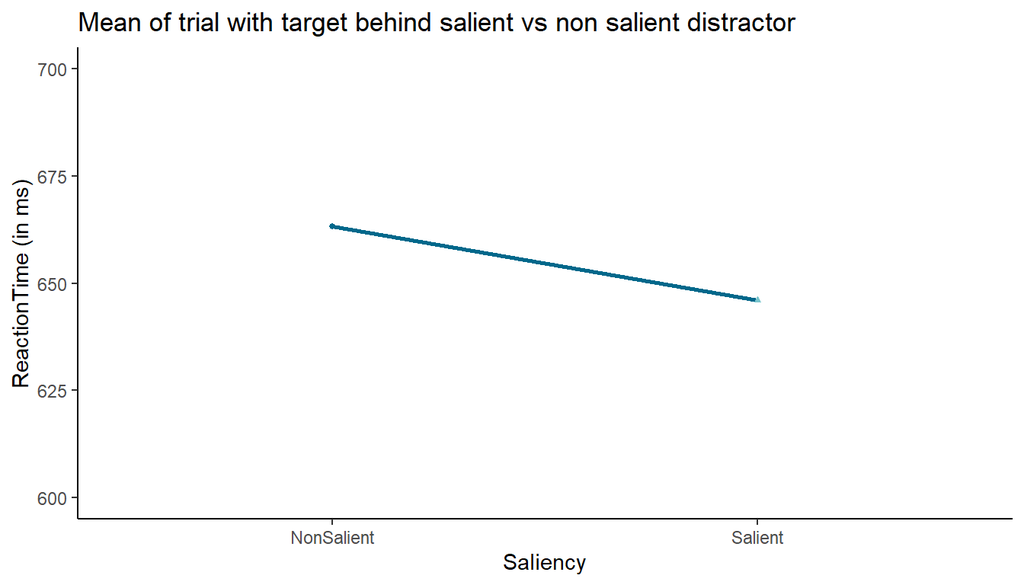

## 3. Interaction of Validity x Saliency in test trials

This analysis is the main one concerning overshadowing.

1. Farouts: Not analyzed further as outliers prove to be a better exclusion criteria

```r
## aggregating the data for farouts and for outliers

Exp7agg_fo <- aggregate(data = Exp7data, RT_ifo~participant+Validity+Saliency, subset = (Condition == "test"), mean)





anova_VS_fo <- ezANOVA(data = Exp7agg_fo,
                       dv = RT_ifo,
                       wid = participant,
                       within = .(Validity, Saliency),type = 3,
                       detailed = TRUE)
panderOptions('table.split.table',300)
pander(anova_VS_fo, style = "rmarkdown", caption = "ANOVA for test trials with Validity and Saliency as factors",split.table = Inf, missing = NA)

# aov_VS_fo <- aov(RT_ifo~(Validity*Saliency)+Error(participant/(Validity*Saliency)), data = Exp7agg_fo)
# summary(aov_VS_fo)

ezPlot(data = Exp7agg_fo,
        dv = RT_ifo,
        wid = participant,
        within = .(Validity, Saliency),
       split = Validity, x = Saliency, do_bars = FALSE)+theme_classic()+
  ggtitle("Interaction effect between saliency and validity for test trials")



#stdInteraction_fo <- ggplot(Exp7agg_fo, aes(x=Saliency, y=RT_ifo,color = Validity))+
#    geom_line(aes(group = Validity, linetype = Validity),size = 1,stat = "summary", fun = "mean",)+
#    geom_point(stat = "summary", fun = "mean", aes(shape = Validity))+ylim(500,600)+
#  scale_color_manual(values = c("deepskyblue4","cadetblue3"))+
#  theme_classic()+ylab("ReactionTime (in ms)")+ggtitle("Interaction of Validity and Saliency")

#ggsave(filename = here("Figures","interaction_fo.png"),stdInteraction_fo)

mean_valEffect_fo <- ezStats(data = Exp7agg_fo,
        dv = RT_ifo,
        wid = participant,
        within_full = .(Saliency,Validity),
        within = .(Saliency),
        diff=.(Validity),
        reverse_diff = TRUE)

pander(mean_valEffect_fo, style = "rmarkdown", title = "Validity effect(invalid-valid) for salient and non salient letters in test trials(farouts)")


pander(t.test(data = Exp7agg_fo, RT_ifo~Validity, subset = (Saliency == "Salient"), paired = TRUE), style = "rmarkdown", caption = "t test for validity effect for salient trials, farouts")
```

[output not shown]

2. Outliers:

The validity effect is not significant, $F = 2.07, p = 0.15$, however the main effect of saliency and the interaction between validity and saliency are significant in the right direction.

```r
##for outliers

Exp7agg_o <- aggregate(data = Exp7data, RT_io~participant+Validity+Saliency, subset = (Condition == "test"), mean)

#ANOVA
anova_VS_o <- ezANOVA(data = Exp7agg_o,
                       dv = RT_io,
                       wid = participant,
                       within = .(Validity, Saliency),
                       detailed = TRUE)
panderOptions('table.split.table',300)
pander(anova_VS_o, style = "rmarkdown", caption = "ANOVA for test trials(w/o outliers) with Validity and Saliency as factors",split.table = Inf, missing = NA)
```

- **ANOVA**:

  | Effect | DFn | DFd | SSn | SSd | F | p | p<.05 | ges |
  | --- | --- | --- | --- | --- | --- | --- | --- | --- |
  | (Intercept) | 1 | 69 | 94930066 | 1807389 | 3624 | 2.24e-61 | * | 0.9789 |
  | Validity | 1 | 69 | 2342 | 77728 | 2.079 | 0.1539 |  | 0.001141 |
  | Saliency | 1 | 69 | 7276 | 88358 | 5.682 | 0.0199 | * | 0.003537 |
  | Validity:Saliency | 1 | 69 | 8895 | 76560 | 8.017 | 0.006069 | * | 0.00432 |

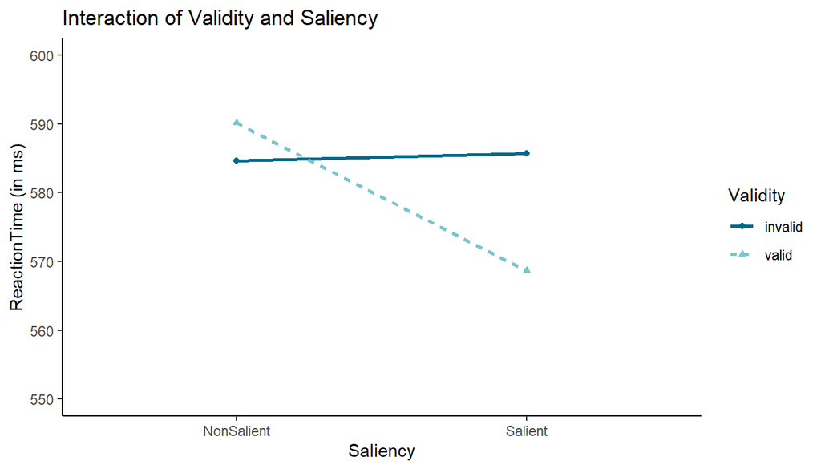

```r
stdInteraction_o <- ggplot(Exp7agg_o, aes(x=Saliency, y=RT_io,color = Validity))+
    geom_line(aes(group = Validity, linetype = Validity),size = 1,stat = "summary", fun = "mean",)+
    geom_point(stat = "summary", fun = "mean", aes(shape = Validity))+
  scale_color_manual(values = c("deepskyblue4","cadetblue3"))+coord_cartesian(ylim = c(550,600))+
  theme_classic()+ylab("ReactionTime (in ms)")+ggtitle("Interaction of Validity and Saliency")
stdInteraction_o
```

```r
#ggsave(filename = here("Figures","interaction_o.png"),stdInteraction_o,width = 6,height = 4)
```

Here is a closer look at the effects, showing the mean difference between valid and invalid in each condition. T tests show that the difference is significant for salient trials and not significant for nonsalient trials

Validity effect(invalid-valid) for salient and non salient test trials(outliers)

| Saliency | N | Mean | SD | FLSD |
| --- | --- | --- | --- | --- |
| NonSalient | 70 | -5.488 | 41.3 | 15.89 |
| Salient | 70 | 17.06 | 52.59 | 15.89 |

t test for validity effect for salient trials, outliers

| Test statistic | df | P value | Alternative hypothesis | mean of the differences |
| --- | --- | --- | --- | --- |
| 2.713 | 69 | 0.008404 * * | two.sided | 17.06 |

t test for validity effect for nonsalient trials, outliers

| Test statistic | df | P value | Alternative hypothesis | mean of the differences |
| --- | --- | --- | --- | --- |
| -1.112 | 69 | 0.2701 | two.sided | -5.488 |

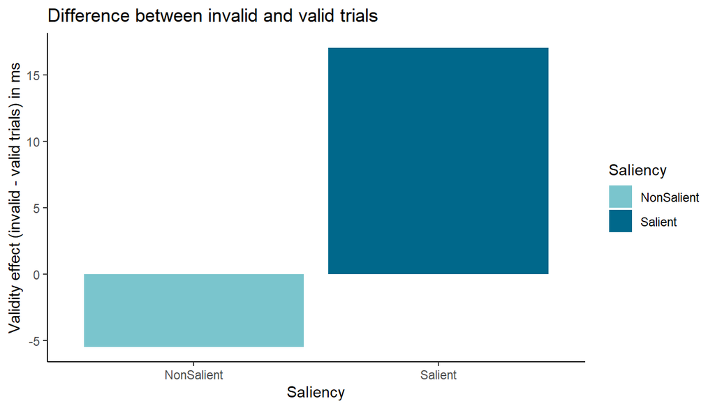

## 4. Error Rate

> Error Rate data show a significant main effect of validity and a significant interaction of validity and Saliency

```r
##aggregate file for Error Rate with Validity and Saliency
Exp7agg_ER <- aggregate(data = Exp7data,ErrorRate~participant+Validity+Saliency,subset = (Condition == "test"),mean)

#to check outlier error rate
Exp7ER <- aggregate(data = Exp7data,ErrorRate~participant,mean)



anova_t_ER <- ezANOVA(data = Exp7agg_ER,
        dv = ErrorRate,
        wid = participant,
        within = .(Saliency,Validity),
        detailed = TRUE)
panderOptions('table.split.table',300)
pander(anova_t_ER, style = 'rmarkdown', caption = "ANOVA results: ErrorRates in test trials", split.table = "Inf", missing = NA)
```

- **ANOVA**:

  | Effect | DFn | DFd | SSn | SSd | F | p | p<.05 | ges |
  | --- | --- | --- | --- | --- | --- | --- | --- | --- |
  | (Intercept) | 1 | 69 | 1.776 | 1.008 | 121.6 | 7.088e-17 | * | 0.4771 |
  | Saliency | 1 | 69 | 0.003571 | 0.2577 | 0.9563 | 0.3315 |  | 0.001832 |
  | Validity | 1 | 69 | 0.028 | 0.3532 | 5.469 | 0.02226 | * | 0.01418 |
  | Saliency:Validity | 1 | 69 | 0.06604 | 0.3277 | 13.9 | 0.0003906 | * | 0.03281 |

```r
anova_out(anova_t_ER)
```

$`--- ANOVA RESULTS ------------------------------------` Effect MSE df1 df2 F p petasq getasq 1 (Intercept) 0.014604555 1 69 121.61 0.000 0.64 0.48 2 Saliency 0.003734472 1 69 0.96 0.332 0.01 0.00 3 Validity 0.005119565 1 69 5.47 0.022 0.07 0.01 4 Saliency:Validity 0.004749482 1 69 13.90 0.000 0.17 0.03

$`--- SPHERICITY TESTS ------------------------------------` [1] “N/A”

$`--- FORMATTED RESULTS ------------------------------------` Effect Text 1 (Intercept) F(1, 69) = 121.61, p < .001, np2 = .64 2 Saliency F(1, 69) = 0.96, p = .332, np2 = .01 3 Validity F(1, 69) = 5.47, p = .022, np2 = .07 4 Saliency:Validity F(1, 69) = 13.90, p < .001, np2 = .17

$`NOTE:` [1] “Reporting unadjusted p-values.”

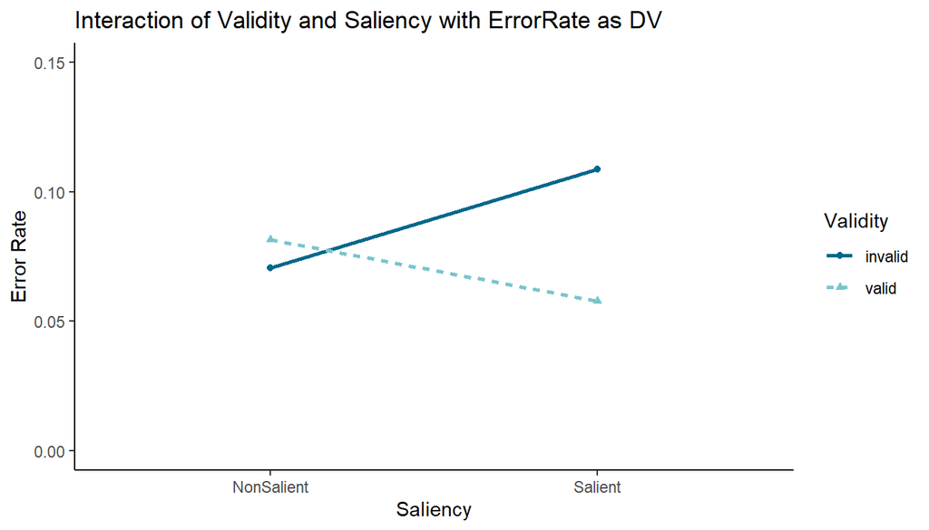

```r
errorrateplot <-  ggplot(Exp7agg_ER, aes(x=Saliency, y=ErrorRate,color = Validity))+
    geom_line(aes(group = Validity, linetype = Validity),size = 1,stat = "summary", fun = "mean",)+
    geom_point(stat = "summary", fun = "mean", aes(shape = Validity))+
  scale_color_manual(values = c("deepskyblue4","cadetblue3"))+coord_cartesian(ylim = c(0,0.15))+
  theme_classic()+ylab("Error Rate")+ggtitle("Interaction of Validity and Saliency with ErrorRate as DV")
errorrateplot
```

```r
#ggsave(filename = here("Figures","ErrorRate.png"),errorrateplot,width=6,height = 4)
```

## 5. Inverse Efficiency scores and Balance Integration Score

1. The Inverse Efficiency score ([Bruyer, R & Brysbaert, M., 2011](https://www.psychologicabelgica.com/articles/abstract/10.5334/pb-51-1-5/)) simply combines the RT and Error Rate into a single variable, $IES = RT/(1-ErrorRate)$
2. The Balance Integration Score (Liesefeld & Jancyzk, 2019) is another form of combining RT and Error Rate but in contrast to the IES, the BIS standardizes the two variables and computes a single variable using this formula, $BIS = z(1-ErrorRate) - z(RT)$

This [research article](https://link.springer.com/article/10.3758/s13428-018-1076-x#Bib1) talks about these methods in depth

Outliers

1. **with IES as Dependant variable**

> There is a significant valdity effect and an interaction with validity and saliency

The ANOVA results along with the interaction plot are shown below. The mean difference graph is also presented to have a different visualization of the effects.

```r
###FOR OUTLIERS

Exp7agg_IES_o <- aggregate(Exp7test[,c("RT_io","ErrorRate","ACC_trials")], by = list(participant = Exp7test$participant,
                                                                       Validity = Exp7test$Validity,
                                                                       Saliency = Exp7test$Saliency), mean,na.rm = TRUE)

Exp7agg_IES_o$IES <- Exp7agg_IES_o$RT_io/(1-Exp7agg_IES_o$ErrorRate)
Exp7agg_IES_o$ZRT <- scale(Exp7agg_IES_o$RT_io)
Exp7agg_IES_o$ZPC <- scale(Exp7agg_IES_o$ACC_trials)
Exp7agg_IES_o$BIS <- Exp7agg_IES_o$ZPC - Exp7agg_IES_o$ZRT

##with IES
anova_t_IES_o <- ezANOVA(data = Exp7agg_IES_o,
        dv = IES,
        wid = participant,
        within = .(Saliency,Validity),
        detailed = TRUE)
panderOptions('table.split.table',300)
pander(anova_t_IES_o, style = 'rmarkdown', caption = "ANOVA results: using IES(outliers)", split.table = "Inf", missing = NA)
```

- **ANOVA**:

  | Effect | DFn | DFd | SSn | SSd | F | p | p<.05 | ges |
  | --- | --- | --- | --- | --- | --- | --- | --- | --- |
  | (Intercept) | 1 | 69 | 113753118 | 1964455 | 3995 | 8.206e-63 | * | 0.9736 |
  | Saliency | 1 | 69 | 810.7 | 310731 | 0.18 | 0.6727 |  | 0.0002632 |
  | Validity | 1 | 69 | 36102 | 348353 | 7.151 | 0.009346 | * | 0.01159 |
  | Saliency:Validity | 1 | 69 | 97644 | 456401 | 14.76 | 0.0002679 | * | 0.03073 |

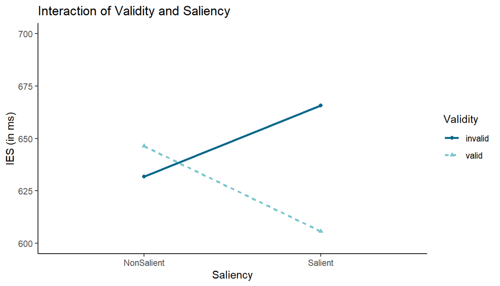

```r
IESinterplot_o <- ggplot(Exp7agg_IES_o, aes(x=Saliency, y=IES,color = Validity))+
    geom_line(aes(group = Validity, linetype = Validity),size = 1,stat = "summary", fun = "mean",)+
    geom_point(stat = "summary", fun = "mean", aes(shape = Validity))+
  scale_color_manual(values = c("deepskyblue4","cadetblue3"))+coord_cartesian(ylim = c(600,700))+
  theme_classic()+ylab("IES (in ms)")+ggtitle("Interaction of Validity and Saliency")
IESinterplot_o
```

```r
#ggsave(filename = here("Figures","IESinterplot_o.png"),IESinterplot_o)

meanIES_o <- ezStats(data = Exp7agg_IES_o,
        dv = IES,
        wid = participant,
        within_full = .(Saliency,Validity),
        within = .(Saliency),
        diff = .(Validity),
        reverse_diff = TRUE)

pander(meanIES_o, style = "rmarkdown", caption = "Mean IES score validity effect")
```

Mean IES score validity effect

| Saliency | N | Mean | SD | FLSD |
| --- | --- | --- | --- | --- |
| NonSalient | 70 | -14.64 | 89.11 | 38.78 |
| Salient | 70 | 60.06 | 124 | 38.78 |

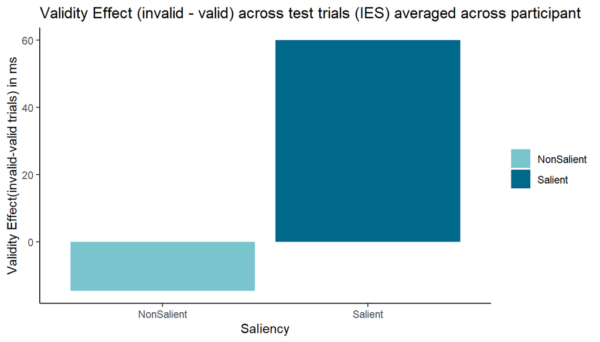

```r
valeffectIES_o <- ggplot(data = meanIES_o, aes(x = Saliency, y = Mean, fill = Saliency))+scale_fill_manual(values = c("cadetblue3","deepskyblue4"))+
  geom_bar(stat = "identity")+
  theme_classic()+
  ylab("Validity Effect(invalid-valid trials) in ms")+theme(legend.title = element_blank())+
  ggtitle("Validity Effect (invalid - valid) across test trials (IES) averaged across participant")
valeffectIES_o
```

```r
#ggsave(filename = here("Figures","valEffectwithIES_o.png"),valeffectIES_o)
```

2. **with BIS as dependent variable**

> There is a significant validity effect and a significant interaction between validity and saliency

The ANOVA and the interaction plot are shown below. *To be noted in the plot: The y axis is represented as a z score*

```r
##with BIS
anova_t_BIS_o <- ezANOVA(data = Exp7agg_IES_o,
        dv = BIS,
        wid = participant,
        within = .(Saliency,Validity),
        detailed = TRUE)
panderOptions('table.split.table',300)
pander(anova_t_BIS_o, style = 'rmarkdown', caption = "ANOVA results: using BIS(outliers)", split.table = "Inf", missing = NA)
```

- **ANOVA**:

  | Effect | DFn | DFd | SSn | SSd | F | p | p<.05 | ges |
  | --- | --- | --- | --- | --- | --- | --- | --- | --- |
  | (Intercept) | 1 | 69 | 1.295e-28 | 255 | 3.503e-29 | 1 |  | 3.096e-31 |
  | Saliency | 1 | 69 | 0.08552 | 43.78 | 0.1348 | 0.7147 |  | 0.0002044 |
  | Validity | 1 | 69 | 6.335 | 54 | 8.095 | 0.005838 | * | 0.01492 |
  | Saliency:Validity | 1 | 69 | 16.79 | 65.46 | 17.7 | 7.652e-05 | * | 0.03859 |

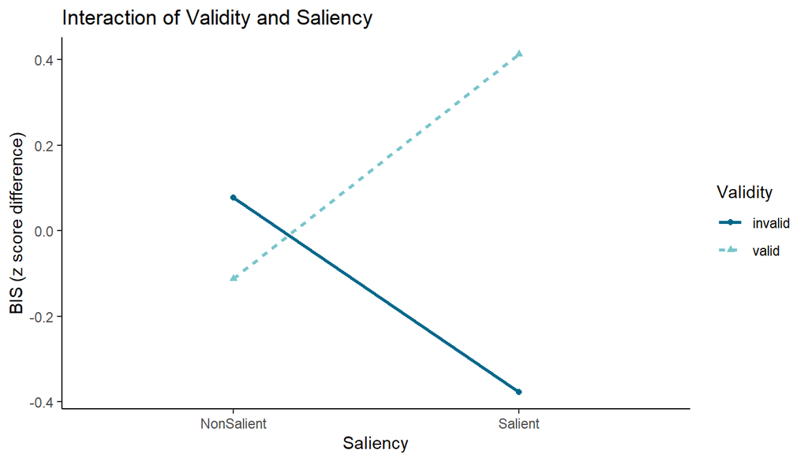

```r
BISinterplot_o <- ggplot(Exp7agg_IES_o, aes(x=Saliency, y=BIS,color = Validity))+
    geom_line(aes(group = Validity, linetype = Validity),size = 1,stat = "summary", fun = "mean",)+
    geom_point(stat = "summary", fun = "mean", aes(shape = Validity))+
  scale_color_manual(values = c("deepskyblue4","cadetblue3"))+
  theme_classic()+ylab("BIS (z score difference)")+ggtitle("Interaction of Validity and Saliency")
BISinterplot_o
```

```r
#ggsave(filename = here("Figures","BISinterplot_o.png"),BISinterplot_o)
```

The mean difference is also significant for both types of scores in the salient condition and not in the nonsalient condition

1. **IES**

Outlier:t. test result of validity effect for salient trials

| Test statistic | df | P value | Alternative hypothesis | mean of the differences |
| --- | --- | --- | --- | --- |
| 4.051 | 69 | 0.0001316 * * * | two.sided | 60.06 |

OUtlier:t. test result of validity effect for nonsalient trials

| Test statistic | df | P value | Alternative hypothesis | mean of the differences |
| --- | --- | --- | --- | --- |
| -1.374 | 69 | 0.1738 | two.sided | -14.64 |

2. **BIS**

Outlier:t. test result of validity effect for salient trials

| Test statistic | df | P value | Alternative hypothesis | mean of the differences |
| --- | --- | --- | --- | --- |
| -4.548 | 69 | 2.248e-05 * * * | two.sided | -0.7906 |

OUtlier:t. test result of validity effect for nonsalient trials

| Test statistic | df | P value | Alternative hypothesis | mean of the differences |
| --- | --- | --- | --- | --- |
| 1.361 | 69 | 0.1778 | two.sided | 0.1889 |

## 6. Previous Occurence Analysis (Distance & Response Type)

Computing a new column that contains the last time/number of trials ago the previous occurrence occurred.

Eg., Distance = 1 means that the last time the distractor appeared was one trial ago, Distance = 5 means the last time the Distractor appeared was 5 trials ago.

The conditions used to satisfy this last occurrence are:

- Whether last trial was test/learn (*Since the trials are intermixed*)
- Whether the Salient **OR** Non salient Distractor appeared.
- The last occurrence was a trial that was answered correctly

```r
Exp7data <- Exp7data%>%select(Condition, SalD,NSalD,Saliency,Validity, everything())

###first is to find out the trials where the previous occurence wa the immediate previous one
Exp7data$Distance <- NA
Exp7data <- Exp7data%>%select(Distance,ACC_trials,everything())
Exp7data <- Exp7data%>%
  mutate(Distance = ifelse((lag(Condition,1)=="test" | lag(Condition,1) == "learn")&
              (lag(SalD,1)== SalD|lag(NSalD,1)==NSalD) &
                            lag(participant,1)==participant &
                            lag(ACC_trials,1)== 1, 1, Distance))

#The number of immediate previous occurences
pander(table(Exp7data$Distance), style = 'rmarkdown', caption = "Table showing the number of immediate previous occurence")
```

Table showing the number of immediate previous occurence

| 1 |
| --- |
| 12668 |

```r
## Now to look at other distances of the last occurrence beyond the immediately preceding one
lagvalue <- 2:20

for(j in lagvalue){
  Exp7data <- Exp7data %>%
    mutate(Distance = ifelse((lag(Condition,j)=="learn"|lag(Condition,j)=="test") &                     (lag(SalD,j)==SalD|lag(NSalD,j)==NSalD) & lag(participant,j)==participant & lag(ACC_trials,j)== 1 & is.na(Distance)==TRUE, j, Distance))
}

pander(table(Exp7data$Distance), style = 'rmarkdown', caption = "Table showing the number of total previous occurences and how far each of them are")
```

Table showing the number of total previous occurences and how far each of them are

| 1 | 2 | 3 | 4 | 5 | 6 | 7 | 8 | 9 | 10 | 11 | 12 | 13 | 14 | 15 | 16 | 17 |
| --- | --- | --- | --- | --- | --- | --- | --- | --- | --- | --- | --- | --- | --- | --- | --- | --- |
| 12668 | 7618 | 4196 | 2091 | 1096 | 592 | 318 | 179 | 106 | 47 | 16 | 17 | 13 | 5 | 4 | 1 | 1 |

### Previous Response

Coding what the previous Response was, whether it was the same or different. This variable is defined as Response Type, which has two factors: Response Change(RC) and Response Repetition (RR)

*To be noted: This does not equate to validity* because the SRB trials can have the combination of invalid prime and invalid probe –> Response Repetition which is confounded by Validity. So every valid probe can have both the Response Type factors based on whether the prime is valid or invalid

```r
Exp7data$ResponseRel <- NA


Exp7data <- Exp7data %>%
  mutate(ResponseRel = ifelse((lag(Condition,1)=="learn" | lag(Condition,1)=="test") & lag(participant,1)==participant & lag(CorrectAnswer,1)== CorrectAnswer & is.na(ResponseRel)==TRUE, "RR", ifelse((lag(Condition,1)=="learn"|lag(Condition,1)=="test") & lag(participant,1)==participant & lag(CorrectAnswer,1)!= CorrectAnswer & is.na(ResponseRel)==TRUE, "RC", ResponseRel)))


pander(table(Exp7data$ResponseRel),style = 'rmarkdown', caption = "Total number of RRs and RCs")
```

Total number of RRs and RCs

| RC | RR |
| --- | --- |
| 15043 | 14007 |

```r
Exp7data <- Exp7data%>%select(ResponseRel, everything())
```

### Overshadowing within SRB

**For more detailed analysis, check Exp7-BindingEffects analyses.html**

Another variable(Overshadow SRB) can also be computed that checks for overshadowing effects within a SRB Trial. So in this case, naturally only the trials with last occurence Distance = 1 will be considered.

The conditions used to determine this variable are:

- Trial $n$ is a test trial and trial $n-1$ is a learn trial and prime trial is accurate.
- Test Trial’s distractor saliency = Salient and also same as the distractors presented in the prime learn trial, then the OvershadowSRB = 1
- Test Trial’s distractor saliency = Nonsalient and also same as the distractors presented in the prime learn trial, then the OvershadowSRB = 2

So essentially, OvershadowSRB tells about the saliency of the test trial (replacing the Saliency factor in the main data)

```r
Exp7data$ProbeSaliency <- NA

Exp7data <- Exp7data%>%select(ProbeSaliency, everything())
Exp7data <- Exp7data %>%
  mutate(ProbeSaliency = ifelse((Condition == "test" & lag(Condition,1) == "learn") &
           lag(SalD,1) == SalD & lag(participant,1)==participant & lag(ACC_trials,1)==1, 1,ProbeSaliency))

Exp7data <- Exp7data %>%
  mutate(ProbeSaliency = ifelse((Condition == "test" & lag(Condition,1) == "learn") &
           lag(NSalD,1)==NSalD & lag(participant,1)==participant & lag(ACC_trials,1)==1 & is.na(ProbeSaliency) == TRUE,2,ProbeSaliency))


table(Exp7data$ProbeSaliency)
```

```
##
##   1   2
## 979 938
```

```r
Exp7data<- Exp7data%>%select(CorrectAnswer, everything())
##creating a dataframe that has only Binding trials preceding with learn
Exp7_OverSRB <- Exp7data %>%
  subset(ProbeSaliency %in% c('1','2'))

Exp7_OverSRB<- Exp7_OverSRB%>%select(CorrectAnswer, everything())
#table(Exp7_OverSRB$ProbeSaliency,Exp7_OverSRB$ResponseRel)
```

#### ANOVA: interaction between Response Type and Saliency for binding trials

Exploratory ANOVA to check how overshadowing looks at a Binding level, using Retrieval effect (ResponseRel) as the variable to check how Saliency affects retrieval.

```r
Exp7overSRB_Agg <- aggregate(Exp7_OverSRB[,c("RT_io","ErrorRate")], by = list(participant=Exp7_OverSRB$participant,ProbeSaliency = Exp7_OverSRB$ProbeSaliency,ResponseRel = Exp7_OverSRB$ResponseRel,Validity=Exp7_OverSRB$Validity), mean, na.rm = TRUE)

Exp7overSRB_Agg <- Exp7overSRB_Agg %>%
   mutate(ProbeSaliency = ifelse(ProbeSaliency == 1, "Salient","NonSalient"))
Exp7overSRB_Agg$ProbeSaliency <- as.factor(Exp7overSRB_Agg$ProbeSaliency)

#ANOVA
#anovaSRB <- ezANOVA(data = Exp7overSRB_Agg,
                    # dv = RT_io,
                    # wid = participant,
                    # within = .(ProbeSaliency,ResponseRel,Validity),
                    # detailed = TRUE)
anovaSRB <- aov(RT_io~(Validity*ProbeSaliency*ResponseRel)+Error(participant/(Validity*ProbeSaliency*ResponseRel)), data = Exp7overSRB_Agg)
pander(anovaSRB, style = 'rmarkdown', caption = "ANOVA results for binding trials with Response Type and Probe Saliency")
```

ANOVA results for binding trials with Response Type and Probe Saliency

|  | Df | Sum Sq | Mean Sq | F value | Pr(>F) |
| --- | --- | --- | --- | --- | --- |
| **Validity** | 1 | 208.7 | 208.7 | 0.007359 | 0.9319 |
| **ProbeSaliency** | 1 | 39895 | 39895 | 1.407 | 0.24 |
| **ResponseRel** | 1 | 13332 | 13332 | 0.4701 | 0.4954 |
| **Validity:ProbeSaliency** | 1 | 133739 | 133739 | 4.716 | 0.0336 |
| **Validity:ResponseRel** | 1 | 59976 | 59976 | 2.115 | 0.1508 |
| **Residuals** | 64 | 1815094 | 28361 | NA | NA |
| **Validity** | 1 | 1856 | 1856 | 0.2955 | 0.5886 |
| **ProbeSaliency** | 1 | 18.5 | 18.5 | 0.002946 | 0.9569 |
| **ResponseRel** | 1 | 3473 | 3473 | 0.5529 | 0.4599 |
| **Validity:ProbeSaliency** | 1 | 14976 | 14976 | 2.384 | 0.1275 |
| **Validity:ResponseRel** | 1 | 474.3 | 474.3 | 0.07551 | 0.7844 |
| **ProbeSaliency:ResponseRel** | 1 | 109.4 | 109.4 | 0.01741 | 0.8954 |
| **Residuals** | 64 | 401994 | 6281 | NA | NA |
| **ProbeSaliency** | 1 | 29388 | 29388 | 4.647 | 0.03487 |
| **ResponseRel** | 1 | 4212 | 4212 | 0.6661 | 0.4174 |
| **Validity:ProbeSaliency** | 1 | 10224 | 10224 | 1.617 | 0.2082 |
| **Validity:ResponseRel** | 1 | 2382 | 2382 | 0.3766 | 0.5416 |
| **ProbeSaliency:ResponseRel** | 1 | 4465 | 4465 | 0.7061 | 0.4039 |
| **Validity:ProbeSaliency:ResponseRel** | 1 | 4130 | 4130 | 0.6531 | 0.422 |
| **Residuals** | 64 | 404711 | 6324 | NA | NA |
| **ResponseRel 1** | 1 | 2667 | 2667 | 0.2901 | 0.5922 |
| **Validity:ProbeSaliency 1** | 1 | 5763 | 5763 | 0.6268 | 0.4318 |
| **Validity:ResponseRel 1** | 1 | 14043 | 14043 | 1.527 | 0.2215 |
| **ProbeSaliency:ResponseRel 1** | 1 | 4820 | 4820 | 0.5242 | 0.472 |
| **Validity:ProbeSaliency:ResponseRel1** | 1 | 2636 | 2636 | 0.2867 | 0.5944 |
| **Residuals 1** | 58 | 533251 | 9194 | NA | NA |
| **Validity:ProbeSaliency 2** | 1 | 55374 | 55374 | 11.95 | 0.0009698 |
| **Validity:ResponseRel 2** | 1 | 741.5 | 741.5 | 0.16 | 0.6905 |
| **ProbeSaliency:ResponseRel 2** | 1 | 375 | 375 | 0.08091 | 0.777 |
| **Validity:ProbeSaliency:ResponseRel2** | 1 | 3542 | 3542 | 0.7641 | 0.3853 |
| **Residuals 2** | 65 | 301282 | 4635 | NA | NA |
| **Validity:ResponseRel 3** | 1 | 11.23 | 11.23 | 0.002181 | 0.9631 |
| **ProbeSaliency:ResponseRel 3** | 1 | 208.5 | 208.5 | 0.0405 | 0.842 |
| **Validity:ProbeSaliency:ResponseRel3** | 1 | 19298 | 19298 | 3.748 | 0.06303 |
| **Residuals 3** | 28 | 144170 | 5149 | NA | NA |
| **ProbeSaliency:ResponseRel 4** | 1 | 5905 | 5905 | 1.025 | 0.3229 |
| **Validity:ProbeSaliency:ResponseRel4** | 1 | 1092 | 1092 | 0.1894 | 0.6678 |
| **Residuals 4** | 21 | 121017 | 5763 | NA | NA |
| **Validity:ProbeSaliency:ResponseRel5** | 1 | 1536 | 1536 | 0.8437 | 0.4553 |
| **Residuals 5** | 2 | 3640 | 1820 | NA | NA |

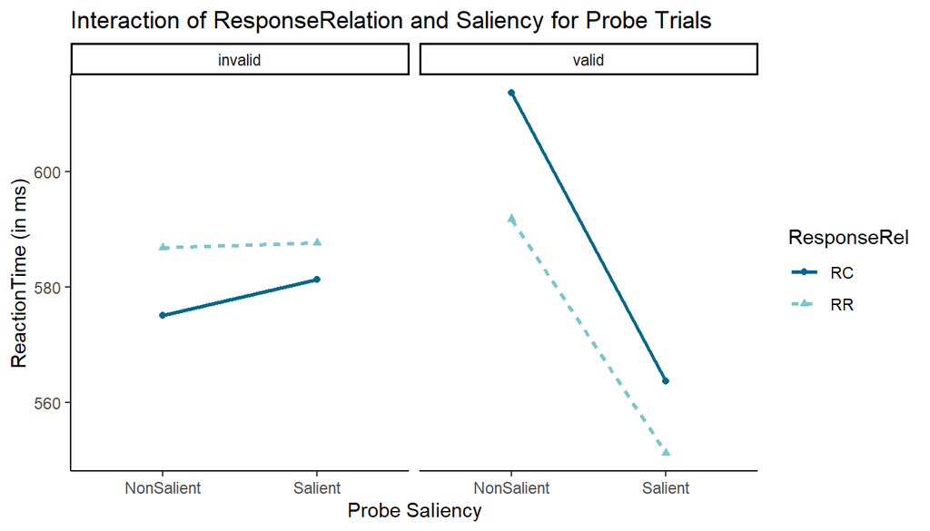

```r
srbInteraction_o <- ggplot(Exp7overSRB_Agg, aes(x=ProbeSaliency, y=RT_io,color = ResponseRel))+
    geom_line(aes(group = ResponseRel, linetype = ResponseRel),size = 1,stat = "summary", fun = "mean",)+
    geom_point(stat = "summary", fun = "mean", aes(shape = ResponseRel))+
  scale_color_manual(values = c("deepskyblue4","cadetblue3"))+xlab("Probe Saliency")+theme_classic()+ylab("ReactionTime (in ms)")+ggtitle("Interaction of ResponseRelation and Saliency for Probe Trials")+facet_grid(.~Validity)
srbInteraction_o
```

```r
#ggsave(filename = here("Figures", "SRBinter_RT.png"), srbInteraction_o)
#ggsave(filename = here("Figures","SRBinterwithRespType.png"), srbInteraction_o)
ggsave(filename = here("Figures","SRB3factors.png"),srbInteraction_o)

pander(t.test(data =Exp7overSRB_Agg, RT_io~ResponseRel, subset = (ProbeSaliency == "Salient"),paired = TRUE), style = "rmarkdown", caption = "T test result for Retrieval effect for Salient probes")
```

[output not shown]

```r
#
pander(t.test(data =Exp7overSRB_Agg, RT_io~ResponseRel, subset = (ProbeSaliency == "NonSalient"),paired = TRUE),style = "rmarkdown", caption = "T test result for Retrieval effect for NonSalient probes")
```

[output not shown]

#### ANOVA: Interaction between validity and Saliency *without* Binding trials

This analysis looks at the interaction of validity and saliency after the Stimulus repetition trials are removed.

> The interaction and the main effects are not significant anymore.

```r
Exp7woSRB <- Exp7data %>%
  filter(Distance != 1)

Exp7woSRB_Agg <- aggregate(Exp7woSRB[,c("RT_io","ErrorRate")], by = list(participant=Exp7woSRB$participant,
                                                                        Saliency = Exp7woSRB$Saliency, Validity = Exp7woSRB$Validity), mean, na.rm = TRUE)

Exp7woSRB_Agg <- Exp7woSRB_Agg %>%
  filter(Saliency%in%c("Salient","NonSalient"))

anovaWoSRB <- ezANOVA(data = Exp7woSRB_Agg,
                      dv = RT_io,
                      wid = participant,
                      within = .(Saliency,Validity),
                      detailed = TRUE)
panderOptions('table.split.table',300)
pander(anovaWoSRB, style = "rmarkdown", caption = "ANOVA after removing stimulus repetition trials", split.table = "Inf", missing=NA)
```

- **ANOVA**:

  | Effect | DFn | DFd | SSn | SSd | F | p | p<.05 | ges |
  | --- | --- | --- | --- | --- | --- | --- | --- | --- |
  | (Intercept) | 1 | 69 | 98783578 | 1875427 | 3634 | 2.034e-61 | * | 0.9784 |
  | Saliency | 1 | 69 | 1204 | 91344 | 0.9097 | 0.3435 |  | 0.0005513 |
  | Validity | 1 | 69 | 3931 | 105040 | 2.582 | 0.1126 |  | 0.001797 |
  | Saliency:Validity | 1 | 69 | 3567 | 111343 | 2.211 | 0.1416 |  | 0.001631 |

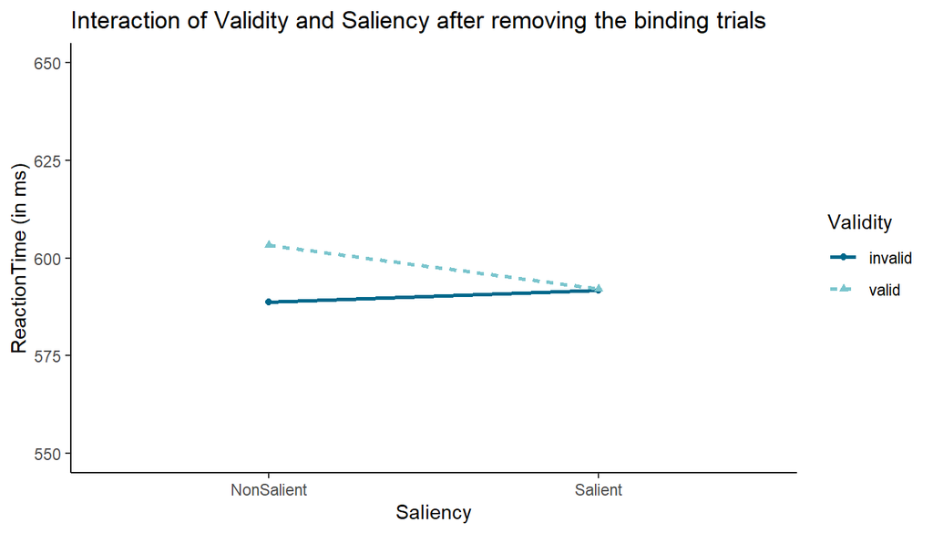

```r
woSRBinter <- ggplot(Exp7woSRB_Agg, aes(x=Saliency, y=RT_io,color = Validity))+
    geom_line(aes(group = Validity, linetype = Validity),size = 1,stat = "summary", fun = "mean",)+
    geom_point(stat = "summary", fun = "mean", aes(shape = Validity))+
  scale_color_manual(values = c("deepskyblue4","cadetblue3"))+coord_cartesian(ylim = c(550,650))+
  theme_classic()+ylab("ReactionTime (in ms)")+ggtitle("Interaction of Validity and Saliency after removing the binding trials")
woSRBinter
```

```r
#ggsave(filename = here("Figures","woSRBinteraction.png"),woSRBinter)
```

### Multi level model

Check other memo titled “Exp7-mlm.html”

# Exploratory Analyses

This exploratory analysis involves the factors of contingency awareness from the guessing trials and the awareness questionnaire responses

## 1. Block Analysis

> There is a significant main effect of Block and the interaction between saliency and validity remains significant.

```r
Exp7data <- Exp7data %>%
  mutate(BlockCount = ifelse(ExpTrials.thisN <= 145, 1, ifelse(ExpTrials.thisN > 145 & ExpTrials.thisN <= 295,2,NA)))

Exp7agg_B_o <- aggregate(data = Exp7data, RT_io~participant+Validity+Saliency+BlockCount, subset = (Condition == "test"), mean)


##Anova with Blocks
anova_t_block <- ezANOVA(data = Exp7agg_B_o,
        dv = RT_io,
        wid = participant,
        within = .(Saliency,Validity,BlockCount),
        detailed = TRUE)
panderOptions('table.split.table',300)
pander(anova_t_block, style = 'rmarkdown', caption = "ANOVA results: with BlockCount", split.table = "Inf", missing = NA)
```

- **ANOVA**:

  | Effect | DFn | DFd | SSn | SSd | F | p | p<.05 | ges |
  | --- | --- | --- | --- | --- | --- | --- | --- | --- |
  | Saliency | 1 | 69 | 12530 | 189412 | 4.565 | 0.03619 | * | 0.01091 |
  | Validity | 1 | 69 | 3836 | 168636 | 1.569 | 0.2145 |  | 0.003364 |
  | BlockCount | 1 | 69 | 39635 | 214107 | 12.77 | 0.000647 | * | 0.03371 |
  | Saliency:Validity | 1 | 69 | 16310 | 163327 | 6.891 | 0.01066 | * | 0.01415 |
  | Saliency:BlockCount | 1 | 69 | 7937 | 138546 | 3.953 | 0.05075 |  | 0.006937 |
  | Validity:BlockCount | 1 | 69 | 269.8 | 128674 | 0.1447 | 0.7049 |  | 0.0002374 |
  | Saliency:Validity:BlockCount | 1 | 69 | 3779 | 133558 | 1.952 | 0.1668 |  | 0.003315 |

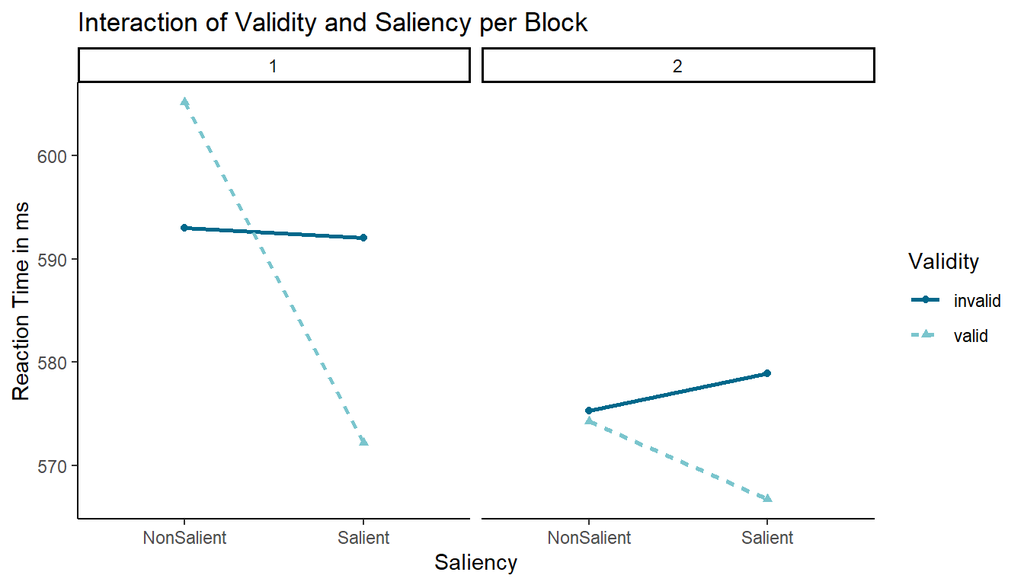

```r
interBlock <- ggplot(Exp7agg_B_o, aes(x=Saliency, y=RT_io,color = Validity))+
    geom_line(aes(group = Validity, linetype = Validity),size = 1,stat = "summary", fun = "mean",)+
    geom_point(stat = "summary", fun = "mean", aes(shape = Validity))+
  scale_color_manual(values = c("deepskyblue4","cadetblue3"))+facet_grid(.~BlockCount)+
  theme_classic()+ylab("Reaction Time in ms")+ggtitle("Interaction of Validity and Saliency per Block")
interBlock
```

```r
#ggsave(filename = here("Figures","InteractionperBlock.png"), interBlock)
```

## 2. Contingency Awareness guessing trials

These are the trials that were presented in between the experiment. First in the beginning among the learn trials and then at the end. There are a total of 20 Guessing trials: - 16 in the beginning that resembled the learn trials where 8 of them had the salient letter alone among other irrelevant blue letters and 8 had the nonsalient letter presented among the blue distractors with a randomly assigned red letter - 4 at the end that resembled the test display - One presentation each of the distractors (2 salient and 2 non salient)

These plots show the overall accuracy of the participants in the guessing trials that were spread across the experiment.

The plot shows that in the Guess trials resembling Learn trials- most participants seemed to be scoring better for the Salient trials compared to the non salient. Similarly in the test trial condition, salient trials seemed to have larger proportion of participants answering accurately than non salient.

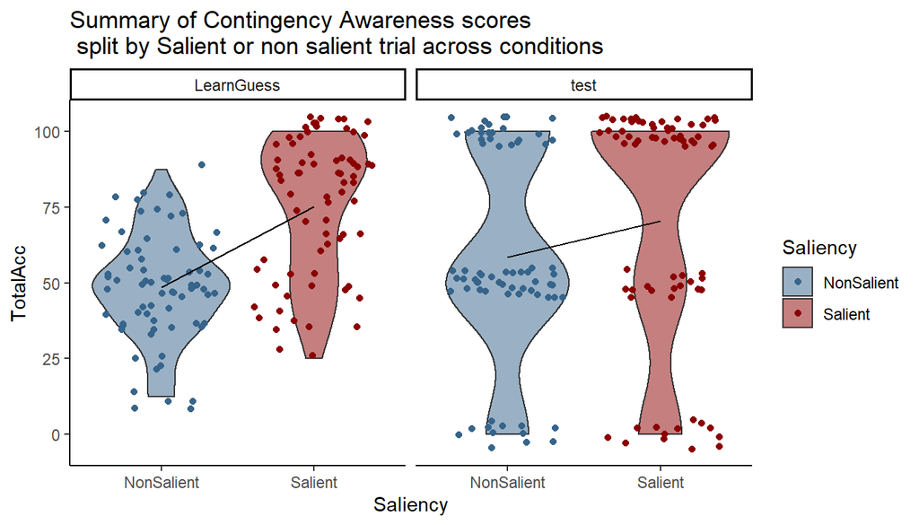

The difference between Accuracy of Guessing trials in the learn trials are as follows:

1. For the Guessing trials in the learn block, the accuracy significantly differs between saliency
2. For the Guessing trials at the end of the experiment resembling test trials, they do not differ significantly but almost $p = 0.07$ *two-sided*.

```r
pander(t.test(data = CA_Summary, TotalAcc~Saliency,subset = (Condition == "LearnGuess"),paired = TRUE), style = "rmarkdown", caption = "t.test comparing scores between salient and nonsalient guessing learn trials")
```

t.test comparing scores between salient and nonsalient guessing learn trials

| Test statistic | df | P value | Alternative hypothesis | mean of the differences |
| --- | --- | --- | --- | --- |
| -8.133 | 70 | 1.04e-11 * * * | two.sided | -26.58 |

```r
pander(t.test(data = CA_Summary, TotalAcc~Saliency,subset = (Condition == "test"),paired = TRUE), style = "rmarkdown", caption = "t.test comparing scores between salient and nonsalient guessing learn trials")
```

t.test comparing scores between salient and nonsalient guessing learn trials

| Test statistic | df | P value | Alternative hypothesis | mean of the differences |
| --- | --- | --- | --- | --- |
| -1.81 | 70 | 0.07452 | two.sided | -11.97 |

## 3. Awareness Questionnaire

The accuracy for the questions related to the salient letter are aggregated and given an overall score of 1 if they answered both the questions right and 0 if one or both are wrong.

For each trial however if they answered correctly, accuracy is marked as 2 and 1 indicates that either they responded incorrectly or do not know.

> 53 people have awareness of contingency for both the salient letters

## 4. Using level of awareness in guessing and question trials as a factor

Now, let’s focus only on the Salient guessing trials as well as questions. Given that the learn guessing trials are the main driving force in creating insight, a variable is created that is a factor of learnAwareness from guessing trials. So using median split, all the participans with more than 50% accuracy in the guessing learn trials are labelled as **“Learn Aware”** and the others are marked as **“Learn Unaware”**.

This is then compared with the participants’ responses in the Questionnaire at the end of the experiment and checked if it matches with their guessing trials’ performance.

```r
#if learnguess salient is high label those participants as learnAware. To be used to check if they correlate with the AwareQ responses of those participants
CA_Summary <- CA_Summary %>%
  mutate(LearnAwareness = ifelse(Condition == "LearnGuess" & Saliency == "Salient" & TotalAcc > 50, "LearnAware", "LearnNotaware"))
pander((table(CA_Summary$LearnAwareness)),style = "rmarkdown")
```

| LearnAware | LearnNotaware |
| --- | --- |
| 53 | 231 |

```r
Exp7agg_A_o <- merge(Exp7agg_o,CA_Summary,by="participant")
#creating df that contains both performances
CompLGAQ <- CA_Summary%>%filter(Condition == "LearnGuess" & Saliency == "Salient")
CompLGAQ <- CompLGAQ %>% filter(participant != 10)
CompLGAQ <- merge(CompLGAQ, A_Summary, by = "participant")

plotLGAQ <- CompLGAQ %>%
  select(c("participant", "TotalAcc","LearnAwareness","SaliencyAware","AwareQSal"))

plotLGAQ <- plotLGAQ %>%
  dplyr::rename(LearnGuessTrials = LearnAwareness,
                SaliencyAwareQuestion = SaliencyAware,
                BothSalAwareQ = AwareQSal)
```

The table below shows the performances in each of the awareness tasks (guessing trials and questionnaire)

```r
pander(plotLGAQ, caption = "Showing the participants' Guessing trial and awareness Questionnaire Performance", format = "html", floating.environment = "sidewaystable")
```

Showing the participants’ Guessing trial and awareness Questionnaire Performance

| participant | TotalAcc | LearnGuessTrials | SaliencyAwareQuestion | BothSalAwareQ |
| --- | --- | --- | --- | --- |
| 100 | 87.5 | LearnAware | 1 | 0 |
| 101 | 50 | LearnNotaware | 2 | 1 |
| 102 | 50 | LearnNotaware | 2 | 1 |
| 103 | 37.5 | LearnNotaware | 2 | 1 |
| 104 | 87.5 | LearnAware | 2 | 1 |
| 105 | 75 | LearnAware | 0 | 0 |
| 106 | 37.5 | LearnNotaware | 2 | 1 |
| 107 | 37.5 | LearnNotaware | 2 | 1 |
| 108 | 100 | LearnAware | 2 | 1 |
| 11 | 100 | LearnAware | 2 | 1 |
| 12 | 75 | LearnAware | 1 | 0 |
| 13 | 37.5 | LearnNotaware | 0 | 0 |
| 17 | 87.5 | LearnAware | 2 | 1 |
| 19 | 87.5 | LearnAware | 2 | 1 |
| 20 | 100 | LearnAware | 2 | 1 |
| 21 | 75 | LearnAware | 2 | 1 |
| 22 | 100 | LearnAware | 2 | 1 |
| 23 | 87.5 | LearnAware | 1 | 0 |
| 24 | 100 | LearnAware | 2 | 1 |
| 25 | 87.5 | LearnAware | 2 | 1 |
| 26 | 87.5 | LearnAware | 2 | 1 |
| 28 | 75 | LearnAware | 2 | 1 |
| 29 | 50 | LearnNotaware | 1 | 0 |
| 30 | 100 | LearnAware | 2 | 1 |
| 32 | 100 | LearnAware | 2 | 1 |
| 33 | 87.5 | LearnAware | 2 | 1 |
| 35 | 50 | LearnNotaware | 2 | 1 |
| 37 | 25 | LearnNotaware | 2 | 1 |
| 39 | 100 | LearnAware | 2 | 1 |
| 40 | 50 | LearnNotaware | 0 | 0 |
| 41 | 87.5 | LearnAware | 2 | 1 |
| 42 | 37.5 | LearnNotaware | 0 | 0 |
| 43 | 100 | LearnAware | 2 | 1 |
| 45 | 87.5 | LearnAware | 2 | 1 |
| 47 | 62.5 | LearnAware | 1 | 0 |
| 48 | 100 | LearnAware | 2 | 1 |
| 50 | 100 | LearnAware | 2 | 1 |
| 51 | 62.5 | LearnAware | 2 | 1 |
| 52 | 87.5 | LearnAware | 2 | 1 |
| 53 | 75 | LearnAware | 2 | 1 |
| 54 | 50 | LearnNotaware | 0 | 0 |
| 55 | 100 | LearnAware | 2 | 1 |
| 56 | 50 | LearnNotaware | 0 | 0 |
| 57 | 87.5 | LearnAware | 2 | 1 |
| 58 | 100 | LearnAware | 2 | 1 |
| 59 | 37.5 | LearnNotaware | 2 | 1 |
| 6 | 37.5 | LearnNotaware | 0 | 0 |
| 61 | 62.5 | LearnAware | 2 | 1 |
| 62 | 100 | LearnAware | 2 | 1 |
| 66 | 62.5 | LearnAware | 1 | 0 |
| 67 | 87.5 | LearnAware | 2 | 1 |
| 68 | 100 | LearnAware | 2 | 1 |
| 69 | 87.5 | LearnAware | 2 | 1 |
| 7 | 75 | LearnAware | 1 | 0 |
| 70 | 62.5 | LearnAware | 2 | 1 |
| 72 | 87.5 | LearnAware | 2 | 1 |
| 73 | 87.5 | LearnAware | 2 | 1 |
| 74 | 100 | LearnAware | 2 | 1 |
| 75 | 62.5 | LearnAware | 2 | 1 |
| 76 | 62.5 | LearnAware | 2 | 1 |
| 77 | 87.5 | LearnAware | 2 | 1 |
| 78 | 87.5 | LearnAware | 0 | 0 |
| 8 | 87.5 | LearnAware | 2 | 1 |
| 80 | 75 | LearnAware | 2 | 1 |
| 81 | 75 | LearnAware | 1 | 0 |
| 87 | 87.5 | LearnAware | 2 | 1 |
| 9 | 50 | LearnNotaware | 2 | 1 |
| 95 | 87.5 | LearnAware | 2 | 1 |
| 97 | 25 | LearnNotaware | 1 | 0 |
| 98 | 100 | LearnAware | 2 | 1 |

### Using Awareness factors to the main aggregate df and evaluating the influence of insight in the interaction of validity and saliency

#### 1. Combining the awareness at the continginecy guessing trial level as well as the Questionnaire

To further evaluate how this awareness knowledge influences the interaction, a new factor was created *AwarenessMatch* that states the level of awareness the participant had and contains 4 factors:

1. Complete Awareness: They scored higher than chance in the learn guessing trials and answered both the awareness questions related to Salient distractors accurately.
2. Guess Awareness Not question: Show higher accuracy in learn guess salient trials but did not answer it accurately in the questionnaire
3. QuestionAwareness Not guess: Answered the salient distractor questions accurately but scored below chance level in the learn guess trials
4. No awareness: Did not have higher accuracy in the learn guess trials and no accuracy in the salient questions.

```r
##selecting pps who show both awareness in trials and questions


Exp7agg_A_o <- merge(Exp7agg_A_o,A_Summary, merge = "participant")
Exp7agg_A_o <- Exp7agg_A_o%>%
  dplyr::rename(LearnGuessTrials = LearnAwareness,
                SaliencyAwareQuestion = SaliencyAware,
                BothSalAwareQ = AwareQSal)
Exp7agg_A_o <- Exp7agg_A_o %>%
  mutate(AwarenessMatch = ifelse(LearnGuessTrials == "LearnAware" & BothSalAwareQ == 1, "CompleteAwareness",
                                 ifelse(LearnGuessTrials == "LearnAware" & BothSalAwareQ == 0,"GuessAwareness Not Question",
                                        ifelse(LearnGuessTrials == "LearnNotaware" & BothSalAwareQ == 1, "QuestionAwareness Not guess",
                                               ifelse(LearnGuessTrials == "LearnNotaware" & BothSalAwareQ == 0,"NoAwareness",NA)))))


##### OLD FACTORS THAT WERE USED #####
# Exp7agg_A_o <- Exp7agg_A_o %>%
#   mutate(GuessSplit = ifelse(TotalAcc > 50, "high","low"))
#
# Exp7agg_A_o <- Exp7agg_A_o %>%
#   group_by(participant)%>%
#   mutate(Awarelevel = ifelse(mean(TotalAcc) > 50, "Aware","less Aware"))
#
# Exp7agg_A_o <- Exp7agg_A_o %>%
#   group_by(participant)%>%
#   mutate(LSAware = ifelse((Condition == "LearnGuess" & Saliency == "Saliency" & TotalAcc > 75), "Aware","UnAware"))
#table(Exp7agg_A_o$LAware)/16 #around 21 people with 100% Acc and 49 people without


anova_VSg_o <- ezANOVA(data = Exp7agg_A_o,
        dv = RT_io,
        wid = participant,
        within = .(Saliency.x,Validity),
        between = .(AwarenessMatch),
        detailed = TRUE)
panderOptions('table.split.table',300)
pander(anova_VSg_o)
```

- **ANOVA**:

  |  | Effect | DFn | DFd | SSn | SSd | F | p | p<.05 | ges |
  | --- | --- | --- | --- | --- | --- | --- | --- | --- | --- |
  | **1** | (Intercept) | 1 | 119 | 162660303 | 2776002 | 6973 | 1.745e-107 | * | 0.9809 |
  | **2** | AwarenessMatch | 3 | 119 | 86324 | 2776002 | 1.233 | 0.3007 |  | 0.0265 |
  | **3** | Saliency.x | 1 | 119 | 10191 | 135671 | 8.939 | 0.003393 | * | 0.003203 |
  | **5** | Validity | 1 | 119 | 7032 | 135695 | 6.167 | 0.01441 | * | 0.002212 |
  | **4** | AwarenessMatch:Saliency.x | 3 | 119 | 1932 | 135671 | 0.5647 | 0.6393 |  | 0.0006087 |
  | **6** | AwarenessMatch:Validity | 3 | 119 | 1188 | 135695 | 0.3472 | 0.7912 |  | 0.0003743 |
  | **7** | Saliency.x:Validity | 1 | 119 | 13600 | 124188 | 13.03 | 0.0004493 | * | 0.00427 |
  | **8** | AwarenessMatch:Saliency.x:Validity | 3 | 119 | 5200 | 124188 | 1.661 | 0.1791 |  | 0.001637 |

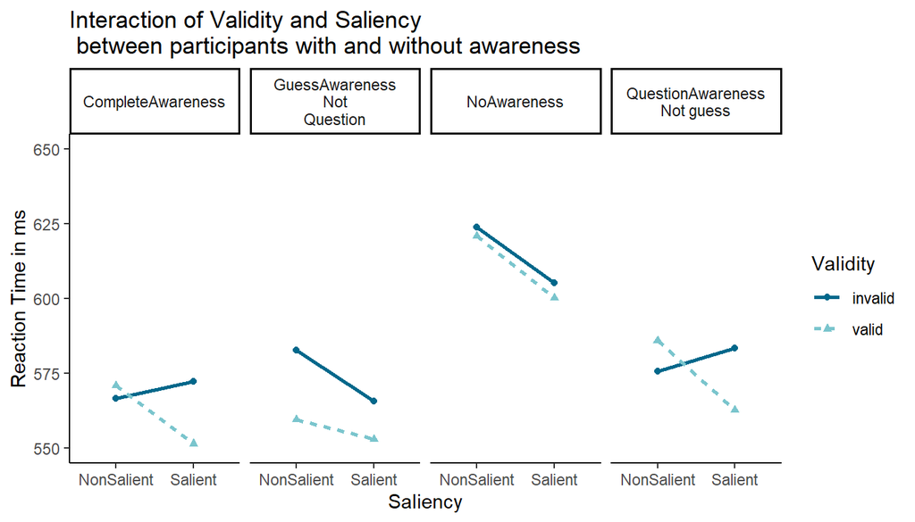

```r
awareInterG <- ggplot(Exp7agg_A_o, aes(x=Saliency.x, y=RT_io,color = Validity))+
    geom_line(aes(group = Validity, linetype = Validity),size = 1,stat = "summary", fun = "mean",)+
    geom_point(stat = "summary", fun = "mean", aes(shape = Validity))+
  scale_color_manual(values = c("deepskyblue4","cadetblue3"))+facet_grid(.~AwarenessMatch, labeller = label_wrap_gen(width = 10))+coord_cartesian(ylim = c(550,650))+xlab("Saliency")+
  theme_classic()+ylab("Reaction Time in ms")+ggtitle("Interaction of Validity and Saliency \n between participants with and without awareness")
awareInterG
```

```r
#ggsave(filename = here("Figures","InteractionwithBothawareness.png"),awareInterG)
```

```r
mean_valEffectA_o <- ezStats(data = Exp7agg_A_o,
        dv = RT_io,
        wid = participant,
        within_full = .(Saliency.x,Validity),
        within = .(Saliency.x),
        diff=.(Validity),
        between = .(AwarenessMatch),
        reverse_diff = TRUE)
pander(t.test(data = Exp7agg_A_o, RT_io~Validity, subset = (Saliency.x == "Salient" & AwarenessMatch == "CompleteAwareness"), paired = TRUE), style = "rmarkdown", caption = "t test for validity effect for salient trials for pp with full awareness")
```

t test for validity effect for salient trials for pp with full awareness

| Test statistic | df | P value | Alternative hypothesis | mean of the differences |
| --- | --- | --- | --- | --- |
| 2.507 | 43 | 0.01602 * | two.sided | 20.82 |

```r
pander(t.test(data = Exp7agg_A_o, RT_io~Validity, subset = (Saliency.x == "Salient" & AwarenessMatch == "GuessAwareness Not Question"), paired = TRUE), style = "rmarkdown", caption = "t test for validity effect for salient trials for pp with partial awareness(only trials)")
```

t test for validity effect for salient trials for pp with partial awareness(only trials)

| Test statistic | df | P value | Alternative hypothesis | mean of the differences |
| --- | --- | --- | --- | --- |
| 0.9375 | 8 | 0.3759 | two.sided | 12.59 |

```r
pander(t.test(data = Exp7agg_A_o, RT_io~Validity, subset = (Saliency.x == "Salient" & AwarenessMatch == "QuestionAwareness Not guess"), paired = TRUE), style = "rmarkdown", caption = "t test for validity effect for salient trials for pp with partial awareness(only question)")
```

t test for validity effect for salient trials for pp with partial awareness(only question)

| Test statistic | df | P value | Alternative hypothesis | mean of the differences |
| --- | --- | --- | --- | --- |
| 4.685 | 167 | 5.778e-06 * * * | two.sided | 20.54 |

```r
pander(t.test(data = Exp7agg_A_o, RT_io~Validity, subset = (Saliency.x == "Salient" & AwarenessMatch == "NoAwareness"), paired = TRUE), style = "rmarkdown", caption = "t test for validity effect for salient trials for pp with no awareness")
```

t test for validity effect for salient trials for pp with no awareness

| Test statistic | df | P value | Alternative hypothesis | mean of the differences |
| --- | --- | --- | --- | --- |
| 1.114 | 58 | 0.2699 | two.sided | 5.018 |

The plot shows that when the participants have complete awareness there seems to be an interaction.

This pattern of interaction is also present for the participants with awareness at the questionnaire level but not at the contingency guessing level. Maybe this could be due to the fact that the questionnaire is presented at the end of the experiment which allowed for better insight.

The pattern is absent in participants who show no awareness and those with awareness only at the guessing trials levels show a pattern wherein the validity effect is larger in nonsalient (~23ms) compared to salient (~12ms).

#### 2. Only using awareness level at the questionnaire level

```r
##for outliers

Exp7agg_AQ_o$AwareQSal <- as.factor(Exp7agg_AQ_o$AwareQSal)
anova_VSAq_o <- ezANOVA(data = Exp7agg_AQ_o,
        dv = RT_io,
        wid = participant,
        within = .(Saliency,Validity),
        between = .(AwareQSal),
        detailed = TRUE)

pander(anova_VSAq_o, style = 'rmarkdown', caption = "ANOVA results with awareness: Outliers excluded",split.table = "Inf", missing = NA)
```

- **ANOVA**:

  |  | Effect | DFn | DFd | SSn | SSd | F | p | p<.05 | ges |
  | --- | --- | --- | --- | --- | --- | --- | --- | --- | --- |
  | **1** | (Intercept) | 1 | 68 | 94930066 | 1755511 | 3677 | 6.243e-61 | * | 0.9794 |
  | **2** | AwareQSal | 1 | 68 | 51878 | 1755511 | 2.01 | 0.1609 |  | 0.02536 |
  | **3** | Saliency | 1 | 68 | 7276 | 86809 | 5.7 | 0.01975 | * | 0.003636 |
  | **5** | Validity | 1 | 68 | 2342 | 77728 | 2.049 | 0.1569 |  | 0.001173 |
  | **4** | AwareQSal:Saliency | 1 | 68 | 1549 | 86809 | 1.214 | 0.2745 |  | 0.0007765 |
  | **6** | AwareQSal:Validity | 1 | 68 | 0.04105 | 77728 | 3.591e-05 | 0.9952 |  | 2.059e-08 |
  | **7** | Saliency:Validity | 1 | 68 | 8895 | 73804 | 8.195 | 0.005578 | * | 0.004441 |
  | **8** | AwareQSal:Saliency:Validity | 1 | 68 | 2756 | 73804 | 2.54 | 0.1157 |  | 0.00138 |

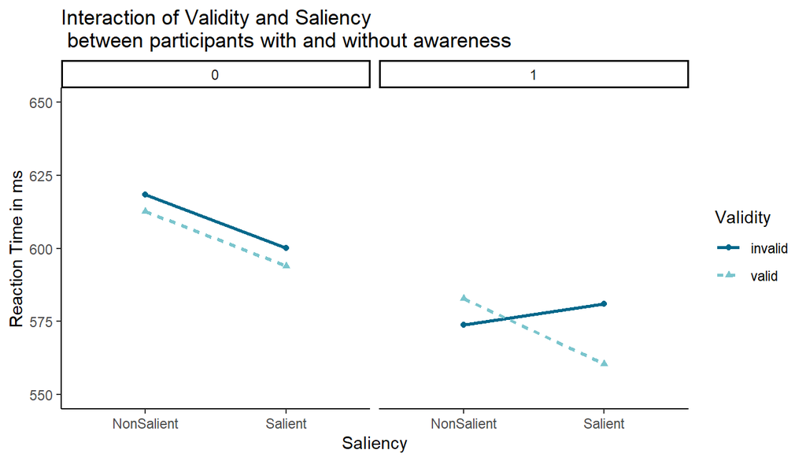

```r
awareQInter <- ggplot(Exp7agg_AQ_o, aes(x=Saliency, y=RT_io,color = Validity))+
    geom_line(aes(group = Validity, linetype = Validity),size = 1,stat = "summary", fun = "mean",)+
    geom_point(stat = "summary", fun = "mean", aes(shape = Validity))+
  scale_color_manual(values = c("deepskyblue4","cadetblue3"))+facet_grid(.~AwareQSal)+coord_cartesian(ylim = c(550,650))+
  theme_classic()+ylab("Reaction Time in ms")+ggtitle("Interaction of Validity and Saliency \n between participants with and without awareness")
awareQInter
```

```r
ggsave(filename = here("Figures","interactionbwAwareness_Questions.png"),awareQInter)

mean_aware_o <- ezStats(data = Exp7agg_AQ_o,
        dv = RT_io,
        wid = participant,
        within_full = .(Saliency,Validity),
        within = .(Saliency),
        between = .(AwareQSal),
        diff=.(Validity),
        reverse_diff = TRUE)

pander(mean_aware_o, style = "rmarkdown", title = "Validity effect(invalid-valid) (outliers excluded) for participants with contingency awareness of salient letters")
```

| AwareQSal | Saliency | N | Mean | SD | FLSD |
| --- | --- | --- | --- | --- | --- |
| 0 | NonSalient | 17 | 5.634 | 35.68 | 22.22 |
| 0 | Salient | 17 | 6.02 | 35.98 | 22.22 |
| 1 | NonSalient | 53 | -9.056 | 42.64 | 22.22 |
| 1 | Salient | 53 | 20.6 | 56.74 | 22.22 |